# Risk Factor Analysis

## Outcome Variable

**Outcome Variable:** wasted

## Predictor Variables

**Intervention Variable:** impsan

**Adjustment Set:**

- arm
- sex
- W_mage
- meducyrs
- feducyrs
- hhwealth_quart
- hfoodsec
- W_mhtcm
- W_nrooms
- W_nchldlt5
- W_parity
- impfloor
- safeh20
- delta_W_mage
- delta_meducyrs
- delta_feducyrs
- delta_hhwealth_quart
- delta_hfoodsec
- delta_W_mhtcm
- delta_W_nrooms
- delta_W_nchldlt5
- delta_W_parity
- delta_impfloor
- delta_safeh20

## Stratifying Variables

The analysis was stratified on these variable(s):

- agecat
- studyid
- country

## Data Summary

| agecat | studyid | country | impsan | wasted | n_cell | n |
| --- | --- | --- | --- | --- | --- | --- |
| Birth | ki0047075b-MAL-ED | BANGLADESH | 0 | 0 | 32 | 222 |
| Birth | ki0047075b-MAL-ED | BANGLADESH | 0 | 1 | 4 | 222 |
| Birth | ki0047075b-MAL-ED | BANGLADESH | 1 | 0 | 152 | 222 |
| Birth | ki0047075b-MAL-ED | BANGLADESH | 1 | 1 | 34 | 222 |
| Birth | ki0047075b-MAL-ED | BRAZIL | 0 | 0 | 3 | 167 |
| Birth | ki0047075b-MAL-ED | BRAZIL | 0 | 1 | 1 | 167 |
| Birth | ki0047075b-MAL-ED | BRAZIL | 1 | 0 | 158 | 167 |
| Birth | ki0047075b-MAL-ED | BRAZIL | 1 | 1 | 5 | 167 |
| Birth | ki0047075b-MAL-ED | INDIA | 0 | 0 | 86 | 188 |
| Birth | ki0047075b-MAL-ED | INDIA | 0 | 1 | 12 | 188 |
| Birth | ki0047075b-MAL-ED | INDIA | 1 | 0 | 72 | 188 |
| Birth | ki0047075b-MAL-ED | INDIA | 1 | 1 | 18 | 188 |
| Birth | ki0047075b-MAL-ED | NEPAL | 0 | 0 | 1 | 166 |
| Birth | ki0047075b-MAL-ED | NEPAL | 0 | 1 | 0 | 166 |
| Birth | ki0047075b-MAL-ED | NEPAL | 1 | 0 | 145 | 166 |
| Birth | ki0047075b-MAL-ED | NEPAL | 1 | 1 | 20 | 166 |
| Birth | ki0047075b-MAL-ED | PERU | 0 | 0 | 179 | 243 |
| Birth | ki0047075b-MAL-ED | PERU | 0 | 1 | 4 | 243 |
| Birth | ki0047075b-MAL-ED | PERU | 1 | 0 | 60 | 243 |
| Birth | ki0047075b-MAL-ED | PERU | 1 | 1 | 0 | 243 |
| Birth | ki0047075b-MAL-ED | SOUTH AFRICA | 0 | 0 | 196 | 211 |
| Birth | ki0047075b-MAL-ED | SOUTH AFRICA | 0 | 1 | 13 | 211 |
| Birth | ki0047075b-MAL-ED | SOUTH AFRICA | 1 | 0 | 2 | 211 |
| Birth | ki0047075b-MAL-ED | SOUTH AFRICA | 1 | 1 | 0 | 211 |
| Birth | ki0047075b-MAL-ED | TANZANIA, UNITED REPUBLIC OF | 0 | 0 | 107 | 109 |
| Birth | ki0047075b-MAL-ED | TANZANIA, UNITED REPUBLIC OF | 0 | 1 | 2 | 109 |
| Birth | ki0047075b-MAL-ED | TANZANIA, UNITED REPUBLIC OF | 1 | 0 | 0 | 109 |
| Birth | ki0047075b-MAL-ED | TANZANIA, UNITED REPUBLIC OF | 1 | 1 | 0 | 109 |
| Birth | ki1017093-NIH-Birth | BANGLADESH | 0 | 0 | 15 | 28 |
| Birth | ki1017093-NIH-Birth | BANGLADESH | 0 | 1 | 4 | 28 |

[output cut: 166 more lines]

The following strata were considered:

- agecat: 24 months, studyid: ki0047075b-MAL-ED, country: BANGLADESH
- agecat: 24 months, studyid: ki0047075b-MAL-ED, country: BRAZIL
- agecat: 24 months, studyid: ki0047075b-MAL-ED, country: INDIA
- agecat: 24 months, studyid: ki0047075b-MAL-ED, country: NEPAL
- agecat: 24 months, studyid: ki0047075b-MAL-ED, country: PERU
- agecat: 24 months, studyid: ki0047075b-MAL-ED, country: SOUTH AFRICA
- agecat: 24 months, studyid: ki0047075b-MAL-ED, country: TANZANIA, UNITED REPUBLIC OF
- agecat: 24 months, studyid: ki1017093-NIH-Birth, country: BANGLADESH
- agecat: 24 months, studyid: ki1017093b-PROVIDE, country: BANGLADESH
- agecat: 24 months, studyid: ki1017093c-NIH-Crypto, country: BANGLADESH
- agecat: 24 months, studyid: ki1114097-CONTENT, country: PERU
- agecat: 24 months, studyid: ki1135781-COHORTS, country: GUATEMALA
- agecat: 24 months, studyid: ki1135781-COHORTS, country: INDIA
- agecat: 24 months, studyid: ki1135781-COHORTS, country: PHILIPPINES
- agecat: 24 months, studyid: ki1148112-LCNI-5, country: MALAWI
- agecat: 24 months, studyid: kiGH5241-JiVitA-3, country: BANGLADESH
- agecat: 24 months, studyid: kiGH5241-JiVitA-4, country: BANGLADESH
- agecat: 6 months, studyid: ki0047075b-MAL-ED, country: BANGLADESH
- agecat: 6 months, studyid: ki0047075b-MAL-ED, country: BRAZIL
- agecat: 6 months, studyid: ki0047075b-MAL-ED, country: INDIA
- agecat: 6 months, studyid: ki0047075b-MAL-ED, country: NEPAL
- agecat: 6 months, studyid: ki0047075b-MAL-ED, country: PERU
- agecat: 6 months, studyid: ki0047075b-MAL-ED, country: SOUTH AFRICA
- agecat: 6 months, studyid: ki0047075b-MAL-ED, country: TANZANIA, UNITED REPUBLIC OF
- agecat: 6 months, studyid: ki1017093-NIH-Birth, country: BANGLADESH
- agecat: 6 months, studyid: ki1017093b-PROVIDE, country: BANGLADESH
- agecat: 6 months, studyid: ki1017093c-NIH-Crypto, country: BANGLADESH
- agecat: 6 months, studyid: ki1114097-CONTENT, country: PERU
- agecat: 6 months, studyid: ki1135781-COHORTS, country: GUATEMALA
- agecat: 6 months, studyid: ki1135781-COHORTS, country: INDIA
- agecat: 6 months, studyid: ki1135781-COHORTS, country: PHILIPPINES
- agecat: 6 months, studyid: ki1148112-LCNI-5, country: MALAWI
- agecat: 6 months, studyid: kiGH5241-JiVitA-3, country: BANGLADESH
- agecat: 6 months, studyid: kiGH5241-JiVitA-4, country: BANGLADESH
- agecat: Birth, studyid: ki0047075b-MAL-ED, country: BANGLADESH
- agecat: Birth, studyid: ki0047075b-MAL-ED, country: BRAZIL
- agecat: Birth, studyid: ki0047075b-MAL-ED, country: INDIA
- agecat: Birth, studyid: ki0047075b-MAL-ED, country: NEPAL
- agecat: Birth, studyid: ki0047075b-MAL-ED, country: PERU
- agecat: Birth, studyid: ki0047075b-MAL-ED, country: SOUTH AFRICA
- agecat: Birth, studyid: ki0047075b-MAL-ED, country: TANZANIA, UNITED REPUBLIC OF
- agecat: Birth, studyid: ki1017093-NIH-Birth, country: BANGLADESH
- agecat: Birth, studyid: ki1017093c-NIH-Crypto, country: BANGLADESH
- agecat: Birth, studyid: ki1114097-CONTENT, country: PERU
- agecat: Birth, studyid: ki1135781-COHORTS, country: GUATEMALA
- agecat: Birth, studyid: ki1135781-COHORTS, country: INDIA
- agecat: Birth, studyid: ki1135781-COHORTS, country: PHILIPPINES
- agecat: Birth, studyid: kiGH5241-JiVitA-3, country: BANGLADESH
- agecat: Birth, studyid: kiGH5241-JiVitA-4, country: BANGLADESH

### Dropped Strata

Some strata were dropped due to rare outcomes:

- agecat: Birth, studyid: ki0047075b-MAL-ED, country: BANGLADESH
- agecat: Birth, studyid: ki0047075b-MAL-ED, country: BRAZIL
- agecat: Birth, studyid: ki0047075b-MAL-ED, country: NEPAL
- agecat: Birth, studyid: ki0047075b-MAL-ED, country: PERU
- agecat: Birth, studyid: ki0047075b-MAL-ED, country: SOUTH AFRICA
- agecat: Birth, studyid: ki0047075b-MAL-ED, country: TANZANIA, UNITED REPUBLIC OF
- agecat: Birth, studyid: ki1017093-NIH-Birth, country: BANGLADESH
- agecat: Birth, studyid: ki1017093c-NIH-Crypto, country: BANGLADESH
- agecat: Birth, studyid: ki1114097-CONTENT, country: PERU
- agecat: 6 months, studyid: ki0047075b-MAL-ED, country: BANGLADESH
- agecat: 6 months, studyid: ki0047075b-MAL-ED, country: BRAZIL
- agecat: 6 months, studyid: ki0047075b-MAL-ED, country: NEPAL
- agecat: 6 months, studyid: ki0047075b-MAL-ED, country: PERU
- agecat: 6 months, studyid: ki0047075b-MAL-ED, country: SOUTH AFRICA
- agecat: 6 months, studyid: ki0047075b-MAL-ED, country: TANZANIA, UNITED REPUBLIC OF
- agecat: 6 months, studyid: ki1017093b-PROVIDE, country: BANGLADESH
- agecat: 6 months, studyid: ki1114097-CONTENT, country: PERU
- agecat: 6 months, studyid: ki1135781-COHORTS, country: GUATEMALA
- agecat: 6 months, studyid: ki1135781-COHORTS, country: PHILIPPINES
- agecat: 6 months, studyid: ki1148112-LCNI-5, country: MALAWI
- agecat: 24 months, studyid: ki0047075b-MAL-ED, country: BRAZIL
- agecat: 24 months, studyid: ki0047075b-MAL-ED, country: NEPAL
- agecat: 24 months, studyid: ki0047075b-MAL-ED, country: PERU
- agecat: 24 months, studyid: ki0047075b-MAL-ED, country: SOUTH AFRICA
- agecat: 24 months, studyid: ki0047075b-MAL-ED, country: TANZANIA, UNITED REPUBLIC OF
- agecat: 24 months, studyid: ki1017093b-PROVIDE, country: BANGLADESH
- agecat: 24 months, studyid: ki1017093c-NIH-Crypto, country: BANGLADESH
- agecat: 24 months, studyid: ki1114097-CONTENT, country: PERU
- agecat: 24 months, studyid: ki1135781-COHORTS, country: GUATEMALA
- agecat: 24 months, studyid: ki1148112-LCNI-5, country: MALAWI

## Methods Detail

We’re interested in the causal parameters $E[Y_a]$ for all values of $a \in \mathcal{A}$. These parameters represent the mean outcome if, possibly contrary to fact, we intervened to set all units to have $A=a$. Under the randomization and positivity assumptions, these are identified by the statistical parameters $\psi_a=E_W[E_{Y|A,W}(Y|A=a,W)]$. In addition, we’re interested in the mean of $Y$, $E[Y]$ under no intervention (the observed mean). We will estimate these parameters by using SuperLearner to fit the relevant likelihood factors – $E_{Y|A,W}(Y|A=a,W)$ and $p(A=a|W)$, and then updating our likelihood fit using a joint TMLE.

For unadjusted analyses ($W=\{\}$), initial likelihoods were estimated using Lrnr_glm to estimate the simple $E(Y|A)$ and Lrnr_mean to estimate $p(A)$. For adjusted analyses, a small library containing Lrnr_glmnet, Lrnr_xgboost, and Lrnr_mean was used.

Having estimated these parameters, we will then use the delta method to estimate relative risks and attributable risks relative to a prespecified baseline level of $A$.

# Results Detail

## Results Plots

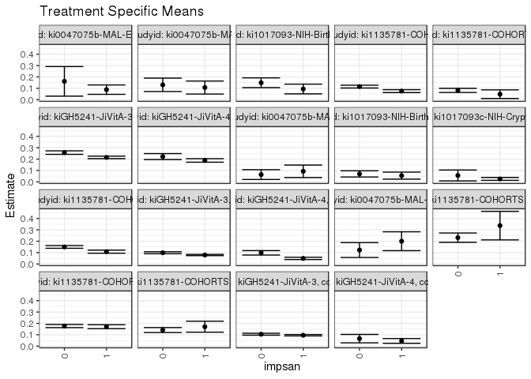

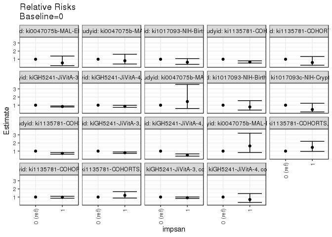

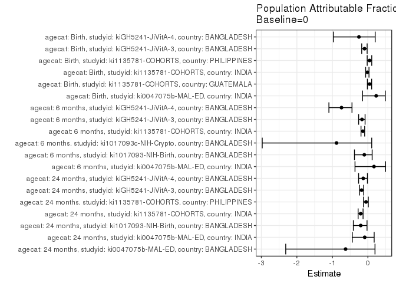

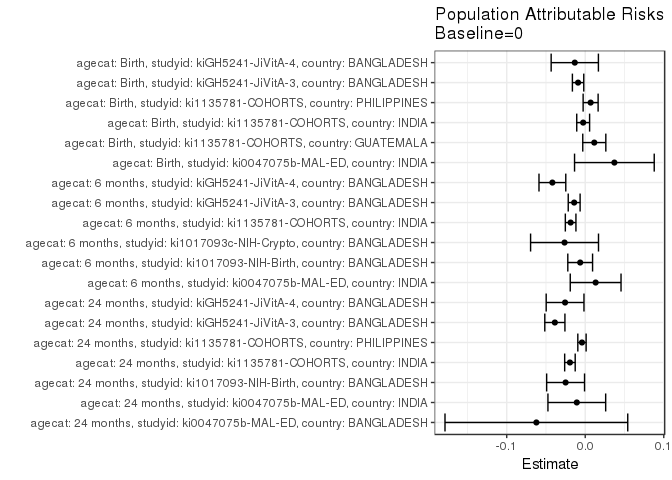

## Results Table

### Parameter: TSM

| agecat | studyid | country | intervention_level | baseline_level | estimate | ci_lower | ci_upper |
| --- | --- | --- | --- | --- | --- | --- | --- |
| Birth | ki0047075b-MAL-ED | INDIA | 0 | NA | 0.1224463 | 0.0573729 | 0.1875196 |
| Birth | ki0047075b-MAL-ED | INDIA | 1 | NA | 0.2000044 | 0.1171443 | 0.2828645 |
| Birth | ki1135781-COHORTS | GUATEMALA | 0 | NA | 0.2312330 | 0.1902292 | 0.2722368 |
| Birth | ki1135781-COHORTS | GUATEMALA | 1 | NA | 0.3372260 | 0.2117463 | 0.4627057 |
| Birth | ki1135781-COHORTS | INDIA | 0 | NA | 0.1765850 | 0.1630415 | 0.1901284 |
| Birth | ki1135781-COHORTS | INDIA | 1 | NA | 0.1708484 | 0.1537093 | 0.1879874 |
| Birth | ki1135781-COHORTS | PHILIPPINES | 0 | NA | 0.1414494 | 0.1194296 | 0.1634692 |
| Birth | ki1135781-COHORTS | PHILIPPINES | 1 | NA | 0.1707736 | 0.1226477 | 0.2188996 |
| Birth | kiGH5241-JiVitA-3 | BANGLADESH | 0 | NA | 0.1050452 | 0.0966071 | 0.1134833 |
| Birth | kiGH5241-JiVitA-3 | BANGLADESH | 1 | NA | 0.0960481 | 0.0898578 | 0.1022384 |
| Birth | kiGH5241-JiVitA-4 | BANGLADESH | 0 | NA | 0.0660196 | 0.0289190 | 0.1031201 |
| Birth | kiGH5241-JiVitA-4 | BANGLADESH | 1 | NA | 0.0458687 | 0.0249804 | 0.0667570 |
| 6 months | ki0047075b-MAL-ED | INDIA | 0 | NA | 0.0640000 | 0.0210013 | 0.1069987 |
| 6 months | ki0047075b-MAL-ED | INDIA | 1 | NA | 0.0925926 | 0.0378079 | 0.1473773 |
| 6 months | ki1017093-NIH-Birth | BANGLADESH | 0 | NA | 0.0698607 | 0.0424859 | 0.0972356 |
| 6 months | ki1017093-NIH-Birth | BANGLADESH | 1 | NA | 0.0546865 | 0.0238719 | 0.0855011 |
| 6 months | ki1017093c-NIH-Crypto | BANGLADESH | 0 | NA | 0.0561798 | 0.0083061 | 0.1040534 |
| 6 months | ki1017093c-NIH-Crypto | BANGLADESH | 1 | NA | 0.0260163 | 0.0134265 | 0.0386060 |
| 6 months | ki1135781-COHORTS | INDIA | 0 | NA | 0.1501467 | 0.1381360 | 0.1621575 |
| 6 months | ki1135781-COHORTS | INDIA | 1 | NA | 0.1081708 | 0.0946547 | 0.1216868 |
| 6 months | kiGH5241-JiVitA-3 | BANGLADESH | 0 | NA | 0.0987150 | 0.0900251 | 0.1074049 |
| 6 months | kiGH5241-JiVitA-3 | BANGLADESH | 1 | NA | 0.0789499 | 0.0733734 | 0.0845263 |
| 6 months | kiGH5241-JiVitA-4 | BANGLADESH | 0 | NA | 0.0981688 | 0.0787833 | 0.1175543 |
| 6 months | kiGH5241-JiVitA-4 | BANGLADESH | 1 | NA | 0.0491824 | 0.0393353 | 0.0590295 |
| 24 months | ki0047075b-MAL-ED | BANGLADESH | 0 | NA | 0.1612903 | 0.0315115 | 0.2910692 |
| 24 months | ki0047075b-MAL-ED | BANGLADESH | 1 | NA | 0.0883978 | 0.0469445 | 0.1298511 |
| 24 months | ki0047075b-MAL-ED | INDIA | 0 | NA | 0.1307366 | 0.0717726 | 0.1897007 |
| 24 months | ki0047075b-MAL-ED | INDIA | 1 | NA | 0.1068050 | 0.0496067 | 0.1640033 |
| 24 months | ki1017093-NIH-Birth | BANGLADESH | 0 | NA | 0.1488394 | 0.1058838 | 0.1917950 |
| 24 months | ki1017093-NIH-Birth | BANGLADESH | 1 | NA | 0.0939323 | 0.0512841 | 0.1365804 |
| 24 months | ki1135781-COHORTS | INDIA | 0 | NA | 0.1150847 | 0.1026271 | 0.1275423 |
| 24 months | ki1135781-COHORTS | INDIA | 1 | NA | 0.0753644 | 0.0625171 | 0.0882116 |
| 24 months | ki1135781-COHORTS | PHILIPPINES | 0 | NA | 0.0817031 | 0.0634823 | 0.0999239 |
| 24 months | ki1135781-COHORTS | PHILIPPINES | 1 | NA | 0.0483871 | 0.0105994 | 0.0861748 |
| 24 months | kiGH5241-JiVitA-3 | BANGLADESH | 0 | NA | 0.2569097 | 0.2414662 | 0.2723531 |
| 24 months | kiGH5241-JiVitA-3 | BANGLADESH | 1 | NA | 0.2150332 | 0.2038304 | 0.2262361 |
| 24 months | kiGH5241-JiVitA-4 | BANGLADESH | 0 | NA | 0.2220603 | 0.1959065 | 0.2482140 |
| 24 months | kiGH5241-JiVitA-4 | BANGLADESH | 1 | NA | 0.1881859 | 0.1727214 | 0.2036503 |

### Parameter: E(Y)

| agecat | studyid | country | intervention_level | baseline_level | estimate | ci_lower | ci_upper |
| --- | --- | --- | --- | --- | --- | --- | --- |
| Birth | ki0047075b-MAL-ED | INDIA | NA | NA | 0.1595745 | 0.1070866 | 0.2120623 |
| Birth | ki1135781-COHORTS | GUATEMALA | NA | NA | 0.2427617 | 0.2030594 | 0.2824640 |
| Birth | ki1135781-COHORTS | INDIA | NA | NA | 0.1739520 | 0.1628271 | 0.1850770 |
| Birth | ki1135781-COHORTS | PHILIPPINES | NA | NA | 0.1483126 | 0.1275443 | 0.1690809 |
| Birth | kiGH5241-JiVitA-3 | BANGLADESH | NA | NA | 0.0959271 | 0.0907227 | 0.1011315 |
| Birth | kiGH5241-JiVitA-4 | BANGLADESH | NA | NA | 0.0527086 | 0.0336587 | 0.0717585 |
| 6 months | ki0047075b-MAL-ED | INDIA | NA | NA | 0.0772532 | 0.0428971 | 0.1116093 |
| 6 months | ki1017093-NIH-Birth | BANGLADESH | NA | NA | 0.0634328 | 0.0427791 | 0.0840865 |
| 6 months | ki1017093c-NIH-Crypto | BANGLADESH | NA | NA | 0.0298295 | 0.0172543 | 0.0424048 |
| 6 months | ki1135781-COHORTS | INDIA | NA | NA | 0.1315471 | 0.1221436 | 0.1409506 |
| 6 months | kiGH5241-JiVitA-3 | BANGLADESH | NA | NA | 0.0846243 | 0.0798159 | 0.0894328 |
| 6 months | kiGH5241-JiVitA-4 | BANGLADESH | NA | NA | 0.0563261 | 0.0473846 | 0.0652676 |
| 24 months | ki0047075b-MAL-ED | BANGLADESH | NA | NA | 0.0990566 | 0.0587480 | 0.1393652 |
| 24 months | ki0047075b-MAL-ED | INDIA | NA | NA | 0.1200000 | 0.0774445 | 0.1625555 |
| 24 months | ki1017093-NIH-Birth | BANGLADESH | NA | NA | 0.1238318 | 0.0925894 | 0.1550741 |
| 24 months | ki1135781-COHORTS | INDIA | NA | NA | 0.0955961 | 0.0861511 | 0.1050412 |
| 24 months | ki1135781-COHORTS | PHILIPPINES | NA | NA | 0.0775428 | 0.0608996 | 0.0941860 |
| 24 months | kiGH5241-JiVitA-3 | BANGLADESH | NA | NA | 0.2182179 | 0.2083049 | 0.2281309 |
| 24 months | kiGH5241-JiVitA-4 | BANGLADESH | NA | NA | 0.1963841 | 0.1829372 | 0.2098310 |

### Parameter: RR

| agecat | studyid | country | intervention_level | baseline_level | estimate | ci_lower | ci_upper |
| --- | --- | --- | --- | --- | --- | --- | --- |
| Birth | ki0047075b-MAL-ED | INDIA | 0 | 0 | 1.0000000 | 1.0000000 | 1.0000000 |
| Birth | ki0047075b-MAL-ED | INDIA | 1 | 0 | 1.6334057 | 0.8326207 | 3.2043573 |
| Birth | ki1135781-COHORTS | GUATEMALA | 0 | 0 | 1.0000000 | 1.0000000 | 1.0000000 |
| Birth | ki1135781-COHORTS | GUATEMALA | 1 | 0 | 1.4583816 | 0.9657424 | 2.2023233 |
| Birth | ki1135781-COHORTS | INDIA | 0 | 0 | 1.0000000 | 1.0000000 | 1.0000000 |
| Birth | ki1135781-COHORTS | INDIA | 1 | 0 | 0.9675136 | 0.8535820 | 1.0966521 |
| Birth | ki1135781-COHORTS | PHILIPPINES | 0 | 0 | 1.0000000 | 1.0000000 | 1.0000000 |
| Birth | ki1135781-COHORTS | PHILIPPINES | 1 | 0 | 1.2073128 | 0.8754768 | 1.6649262 |
| Birth | kiGH5241-JiVitA-3 | BANGLADESH | 0 | 0 | 1.0000000 | 1.0000000 | 1.0000000 |
| Birth | kiGH5241-JiVitA-3 | BANGLADESH | 1 | 0 | 0.9143503 | 0.8270021 | 1.0109243 |
| Birth | kiGH5241-JiVitA-4 | BANGLADESH | 0 | 0 | 1.0000000 | 1.0000000 | 1.0000000 |
| Birth | kiGH5241-JiVitA-4 | BANGLADESH | 1 | 0 | 0.6947739 | 0.3379496 | 1.4283514 |
| 6 months | ki0047075b-MAL-ED | INDIA | 0 | 0 | 1.0000000 | 1.0000000 | 1.0000000 |
| 6 months | ki0047075b-MAL-ED | INDIA | 1 | 0 | 1.4467593 | 0.5910108 | 3.5415805 |
| 6 months | ki1017093-NIH-Birth | BANGLADESH | 0 | 0 | 1.0000000 | 1.0000000 | 1.0000000 |
| 6 months | ki1017093-NIH-Birth | BANGLADESH | 1 | 0 | 0.7827925 | 0.3942220 | 1.5543632 |
| 6 months | ki1017093c-NIH-Crypto | BANGLADESH | 0 | 0 | 1.0000000 | 1.0000000 | 1.0000000 |
| 6 months | ki1017093c-NIH-Crypto | BANGLADESH | 1 | 0 | 0.4630894 | 0.1738081 | 1.2338427 |
| 6 months | ki1135781-COHORTS | INDIA | 0 | 0 | 1.0000000 | 1.0000000 | 1.0000000 |
| 6 months | ki1135781-COHORTS | INDIA | 1 | 0 | 0.7204337 | 0.6214453 | 0.8351898 |
| 6 months | kiGH5241-JiVitA-3 | BANGLADESH | 0 | 0 | 1.0000000 | 1.0000000 | 1.0000000 |
| 6 months | kiGH5241-JiVitA-3 | BANGLADESH | 1 | 0 | 0.7997758 | 0.7166237 | 0.8925763 |
| 6 months | kiGH5241-JiVitA-4 | BANGLADESH | 0 | 0 | 1.0000000 | 1.0000000 | 1.0000000 |
| 6 months | kiGH5241-JiVitA-4 | BANGLADESH | 1 | 0 | 0.5009985 | 0.3785226 | 0.6631032 |
| 24 months | ki0047075b-MAL-ED | BANGLADESH | 0 | 0 | 1.0000000 | 1.0000000 | 1.0000000 |
| 24 months | ki0047075b-MAL-ED | BANGLADESH | 1 | 0 | 0.5480663 | 0.2159592 | 1.3908957 |
| 24 months | ki0047075b-MAL-ED | INDIA | 0 | 0 | 1.0000000 | 1.0000000 | 1.0000000 |
| 24 months | ki0047075b-MAL-ED | INDIA | 1 | 0 | 0.8169475 | 0.4134021 | 1.6144169 |
| 24 months | ki1017093-NIH-Birth | BANGLADESH | 0 | 0 | 1.0000000 | 1.0000000 | 1.0000000 |
| 24 months | ki1017093-NIH-Birth | BANGLADESH | 1 | 0 | 0.6310981 | 0.3687035 | 1.0802304 |
| 24 months | ki1135781-COHORTS | INDIA | 0 | 0 | 1.0000000 | 1.0000000 | 1.0000000 |
| 24 months | ki1135781-COHORTS | INDIA | 1 | 0 | 0.6548601 | 0.5355592 | 0.8007364 |
| 24 months | ki1135781-COHORTS | PHILIPPINES | 0 | 0 | 1.0000000 | 1.0000000 | 1.0000000 |
| 24 months | ki1135781-COHORTS | PHILIPPINES | 1 | 0 | 0.5922308 | 0.2628888 | 1.3341660 |
| 24 months | kiGH5241-JiVitA-3 | BANGLADESH | 0 | 0 | 1.0000000 | 1.0000000 | 1.0000000 |
| 24 months | kiGH5241-JiVitA-3 | BANGLADESH | 1 | 0 | 0.8369994 | 0.7762958 | 0.9024497 |
| 24 months | kiGH5241-JiVitA-4 | BANGLADESH | 0 | 0 | 1.0000000 | 1.0000000 | 1.0000000 |
| 24 months | kiGH5241-JiVitA-4 | BANGLADESH | 1 | 0 | 0.8474540 | 0.7316190 | 0.9816288 |

### Parameter: PAR

| agecat | studyid | country | intervention_level | baseline_level | estimate | ci_lower | ci_upper |
| --- | --- | --- | --- | --- | --- | --- | --- |
| Birth | ki0047075b-MAL-ED | INDIA | 0 | NA | 0.0371282 | -0.0136138 | 0.0878702 |
| Birth | ki1135781-COHORTS | GUATEMALA | 0 | NA | 0.0115287 | -0.0031570 | 0.0262144 |
| Birth | ki1135781-COHORTS | INDIA | 0 | NA | -0.0026329 | -0.0108251 | 0.0055593 |
| Birth | ki1135781-COHORTS | PHILIPPINES | 0 | NA | 0.0068633 | -0.0026844 | 0.0164109 |
| Birth | kiGH5241-JiVitA-3 | BANGLADESH | 0 | NA | -0.0091181 | -0.0163515 | -0.0018847 |
| Birth | kiGH5241-JiVitA-4 | BANGLADESH | 0 | NA | -0.0133109 | -0.0433975 | 0.0167757 |
| 6 months | ki0047075b-MAL-ED | INDIA | 0 | NA | 0.0132532 | -0.0190801 | 0.0455865 |
| 6 months | ki1017093-NIH-Birth | BANGLADESH | 0 | NA | -0.0064279 | -0.0221984 | 0.0093426 |
| 6 months | ki1017093c-NIH-Crypto | BANGLADESH | 0 | NA | -0.0263502 | -0.0696000 | 0.0168995 |
| 6 months | ki1135781-COHORTS | INDIA | 0 | NA | -0.0185996 | -0.0253462 | -0.0118530 |
| 6 months | kiGH5241-JiVitA-3 | BANGLADESH | 0 | NA | -0.0140907 | -0.0216526 | -0.0065287 |
| 6 months | kiGH5241-JiVitA-4 | BANGLADESH | 0 | NA | -0.0418427 | -0.0588997 | -0.0247857 |
| 24 months | ki0047075b-MAL-ED | BANGLADESH | 0 | NA | -0.0622337 | -0.1786024 | 0.0541350 |
| 24 months | ki0047075b-MAL-ED | INDIA | 0 | NA | -0.0107366 | -0.0475003 | 0.0260270 |
| 24 months | ki1017093-NIH-Birth | BANGLADESH | 0 | NA | -0.0250076 | -0.0491415 | -0.0008738 |
| 24 months | ki1135781-COHORTS | INDIA | 0 | NA | -0.0194886 | -0.0261883 | -0.0127889 |
| 24 months | ki1135781-COHORTS | PHILIPPINES | 0 | NA | -0.0041603 | -0.0094436 | 0.0011230 |
| 24 months | kiGH5241-JiVitA-3 | BANGLADESH | 0 | NA | -0.0386918 | -0.0515128 | -0.0258708 |
| 24 months | kiGH5241-JiVitA-4 | BANGLADESH | 0 | NA | -0.0256762 | -0.0497353 | -0.0016170 |

### Parameter: PAF

| agecat | studyid | country | intervention_level | baseline_level | estimate | ci_lower | ci_upper |
| --- | --- | --- | --- | --- | --- | --- | --- |
| Birth | ki0047075b-MAL-ED | INDIA | 0 | NA | 0.2326701 | -0.1513908 | 0.4886227 |
| Birth | ki1135781-COHORTS | GUATEMALA | 0 | NA | 0.0474897 | -0.0147124 | 0.1058789 |
| Birth | ki1135781-COHORTS | INDIA | 0 | NA | -0.0151360 | -0.0633920 | 0.0309302 |
| Birth | ki1135781-COHORTS | PHILIPPINES | 0 | NA | 0.0462756 | -0.0200130 | 0.1082562 |
| Birth | kiGH5241-JiVitA-3 | BANGLADESH | 0 | NA | -0.0950525 | -0.1739022 | -0.0214990 |
| Birth | kiGH5241-JiVitA-4 | BANGLADESH | 0 | NA | -0.2525378 | -0.9735445 | 0.2050593 |
| 6 months | ki0047075b-MAL-ED | INDIA | 0 | NA | 0.1715556 | -0.3630443 | 0.4964799 |
| 6 months | ki1017093-NIH-Birth | BANGLADESH | 0 | NA | -0.1013338 | -0.3782847 | 0.1199669 |
| 6 months | ki1017093c-NIH-Crypto | BANGLADESH | 0 | NA | -0.8833601 | -2.9753519 | 0.1077406 |
| 6 months | ki1135781-COHORTS | INDIA | 0 | NA | -0.1413911 | -0.1940296 | -0.0910732 |
| 6 months | kiGH5241-JiVitA-3 | BANGLADESH | 0 | NA | -0.1665083 | -0.2605860 | -0.0794517 |
| 6 months | kiGH5241-JiVitA-4 | BANGLADESH | 0 | NA | -0.7428651 | -1.0979794 | -0.4478592 |
| 24 months | ki0047075b-MAL-ED | BANGLADESH | 0 | NA | -0.6282642 | -2.3133126 | 0.1998206 |
| 24 months | ki0047075b-MAL-ED | INDIA | 0 | NA | -0.0894719 | -0.4412012 | 0.1764168 |
| 24 months | ki1017093-NIH-Birth | BANGLADESH | 0 | NA | -0.2019483 | -0.4099498 | -0.0246321 |
| 24 months | ki1135781-COHORTS | INDIA | 0 | NA | -0.2038635 | -0.2755343 | -0.1362198 |
| 24 months | ki1135781-COHORTS | PHILIPPINES | 0 | NA | -0.0536518 | -0.1231776 | 0.0115704 |
| 24 months | kiGH5241-JiVitA-3 | BANGLADESH | 0 | NA | -0.1773081 | -0.2389220 | -0.1187584 |
| 24 months | kiGH5241-JiVitA-4 | BANGLADESH | 0 | NA | -0.1307446 | -0.2616616 | -0.0134123 |